# Day 4: Intro to pathway analysis supplemental notebook

Jaclyn Taroni

2021-07-01

## Introduction

This notebook addresses some questions that came up during or after the fourth day of the CCDL workshop.

- Saving GSEA plots for all significant pathways
- GSEA significance

### How to use this notebook:

While it is fine to just read this page as is, if you want to get the Rmarkdown notebook itself to work with, you can follow the following steps:

1. Click the `Code` button in the upper right of this page and choose `Download Rmd` to save this notebook (`2021-07-01_muddiest_points.Rmd`) to your computer. If you have RStudio installed on your computer, you can then open the file directly.

Otherwise you can add it to the CCDL RStudio server to work with it there with the following additional steps:

2. Navigate to RStudio server.
3. In the `File` pane, navigate to `training-modules/scRNA-seq`.
4. Click the `Upload` button in the `File` pane.
5. Click `Choose file` and find this `Rmd` file on your computer, then click `OK`

Now you can open up this file and run it on the Server.

## Libraries

```r
library(magrittr)
# Package to run GSEA
library(clusterProfiler)
# Package that contains the MSigDB gene sets in tidy format
library(msigdbr)
```

For some later plots, we are going to use the `ggridges` package, which may not be installed, so let’s install it here (only if it is not already installed):

```r
if (! "ggridges" %in% installed.packages()){
  install.package("ggridges")
}
```

## Saving GSEA plots for all significant results

### Prep gene level statistics

Prep the marker genes for GSEA the same way we did for instruction.

```r
# Use the marker genes from cluster 1 that already have gene symbols associated
# with them
input_file <- file.path("analysis",
                        "hodgkins",
                        "markers",
                        "cluster01_markers_with_gene_symbols.tsv")

# Read in the cluster 1 marker genes table
markers_df <- readr::read_tsv(input_file)
# Remove duplicates
filtered_markers_df <- markers_df %>%
  # Sort so that the highest absolute values of the summary log2 fold change are
  # at the top
  dplyr::arrange(dplyr::desc(abs(summary.logFC))) %>%
  # Filter out the duplicated rows using `dplyr::distinct()`
  dplyr::distinct(gene_symbol, .keep_all = TRUE)

# Ranked vector of genes
lfc_vector <- filtered_markers_df %>%
  # Extract a vector of `summary.logFC` named by `gene_symbol`
  dplyr::pull(summary.logFC, name = gene_symbol)
lfc_vector <- sort(lfc_vector, decreasing = TRUE)
```

### Prep gene sets

We’ll use the same gene sets we used during instruction; they are from the C7 immunologic collection at MSigDB.

```r
hs_immunologic_df <- msigdbr(species = "Homo sapiens",
                             category = "C7")
```

### Run GSEA

Run GSEA using the same parameters as we did during instruction.

```r
gsea_results <- GSEA(geneList = lfc_vector,  # ordered ranked gene list
                     minGSSize = 25,  # minimum gene set size
                     maxGSSize = 500,  # maximum gene set set
                     pvalueCutoff = 0.05,
                     pAdjustMethod = "BH",  # correction for multiple hypothesis testing
                     TERM2GENE = dplyr::select(hs_immunologic_df,
                                               gs_name,
                                               gene_symbol))
```

```
preparing geneSet collections...
GSEA analysis...
For some pathways, in reality P-values are less than 1e-10. You can set the `eps` argument to zero for better estimation.leading edge analysis...
done...
```

Let’s get the gene set names for all of the significant gene sets.

```r
significant_gene_sets <- gsea_results@result %>%  # tabular results
  dplyr::filter(p.adjust < 0.05) %>%  # filter based on adjusted p-value
  dplyr::pull(ID)  # pull the gene set names as a vector
```

### Save a GSEA plot for every significant

First, let’s make sure we have a `plots/hodgkins/gsea` directory to hold our output.

```r
plots_dir <- file.path("plots", "hodgkins", "gsea")
if (!dir.exists(plots_dir)) {
  dir.create(plots_dir, recursive = TRUE)
}
```

Now, let’s look at (one) way to save each of the significant pathways using `purrr`.

```r
# Create a list of plots, where each element of the list will be
plot_list <- purrr::map(
  as.list(significant_gene_sets),   # Make a list of significant gene sets
  ~ enrichplot::gseaplot(gsea_results,
                         geneSetID = .x,  # Pathway name
                         title = .x # Pathway name
  )
)

# Now we need to "walk" through both the plots and the gene set names
purrr::walk2(
  plot_list, # the list of plots
  as.list(significant_gene_sets),  # the list of pathway names
  ~ ggplot2::ggsave( # the function we are applying
      plot = .x,   # plot itself (from the first list)
      filename = file.path(plots_dir,
                           paste0(.y, # pathway name (from the second list)
                                  "_gsea_plot.png")),
      width = 11,
      height = 7
    )
)
```

Here’s how to do the same thing by looping through the vector of the significant pathway names with a `for` loop!

```r
for (pathway in significant_gene_sets) {
  # Create the plot and assign it to `p`
  p <- enrichplot::gseaplot(gsea_results,
                            geneSetID = pathway,  # Pathway name
                            title = pathway) # Pathway name
  # Save the plot, using the pathway name as part of the filename
  # Note that this will write over the files we saved with the purrr method!
  ggplot2::ggsave(plot = p,
                  filename = file.path(plots_dir, paste0(pathway, "_gsea_plot.png")),
                  width = 11, height = 7)
}
```

## A little more on GSEA significance

There was a question about how one gene set could be not be statistically significant if it had a higher absolute enrichment score than a significant gene set.

Each pathway used as input to GSEA is tested for significance through permutation testing.

If we look at [Figure 1A](https://www.biorxiv.org/content/biorxiv/early/2021/02/01/060012/F1.large.jpg) from [Korotkevich *et al.* (2021)](https://doi.org/10.1101/060012), the paper that describes the fgsea algorithm “under the hood” of `GSEA()`:

[figure not shown]

**We can see that the uncorrected p-value is calculated from a distribution of enrichment scores generated by randomly sampling *gene sets of the same size*.**

Different gene set of different sizes will produce different distributions and part of the rationale for *normalized* enrichment scores (NES) are to make enrichment scores from pathways/gene sets of different sizes more comparable.

Let’s look at this in a little more depth by generating random gene sets of different sizes and examining the enrichment scores that we get back out of `GSEA()`.

```r
# Create a vector of all gene symbols
all_genes <- markers_df$gene_symbol

# Make a list of integers that indicate the random gene set sizes
gene_set_size <- list(15, 25, 50, 100, 250, 500)

# Set number of replicates
nreps <- 1000
# Generate 1000 random gene sets of each size
random_gene_sets <- rep(gene_set_size, nreps) %>%  # Repeat gene sizes so we run `nreps` times
  purrr::map(
    # Sample the vector of all genes, choosing the number of items specified
    # in the element of gene set size
    ~ base::sample(x = all_genes,
                   size = .x)
  )

# We will include the size of the gene set in the gene set name
# Start by taking the length of each pathway and appending "pathway_" to that
# number
lengths_vector <- random_gene_sets %>%
  # Get the length of each gene set (number of genes)
  purrr::map(~ length(.x)) %>%
  # Make it "pathway_<gene set size>"
  purrr::map(~ paste0("pathway_", .x)) %>%
  # Return a vector
  purrr::flatten_chr()

# Add the names in lengths_vector to the list - "pathway_<gene set size>"
random_gene_sets <- random_gene_sets %>%
  # make.names() appends a "version" if something is not unique
  purrr::set_names(nm = make.names(lengths_vector, unique = TRUE))

# Make this a data frame that GSEA() can use
random_gene_set_df <- reshape2::melt(random_gene_sets) %>%
  dplyr::select(gene_set = L1, symbol = value)
```

Now perform GSEA using these random gene sets of different sizes.

```r
gsea_random <- GSEA(geneList = lfc_vector,  # ordered ranked gene list
                     minGSSize = 15,  # minimum gene set size
                     maxGSSize = 500,  # maximum gene set set
                     pvalueCutoff = 1,  # Return everything!
                     pAdjustMethod = "BH",  # correction for multiple hypothesis testing
                     TERM2GENE = random_gene_set_df)  # data frame with randomly generated gene sets
```

```
preparing geneSet collections...
GSEA analysis...
For some of the pathways the P-values were likely overestimated. For such pathways log2err is set to NA.leading edge analysis...
done...
```

Let’s get the enrichment scores and normalized enrichment scores in a data frame we’ll use for plotting.

```r
random_es <- gsea_random@result %>%
  # Just the pathway name, enrichment score, and normalized enrichment score
  dplyr::select(ID, enrichmentScore, NES) %>%
  # Create a new column that includes the gene set size as a factor in ascending
  # order
  dplyr::mutate(pathway_size = factor(
    stringr::str_remove(stringr::str_remove(ID ,"\\..*"), ".*\\_" ),
    levels = c(15, 25, 50, 100, 250, 500)
  ))

# Take a peek
head(random_es)
```

|  | ID | enrichmentScore | NES | pathway_size |
| --- | --- | --- | --- | --- |
| pathway_250.455 | pathway_250.455 | 0.6960121 | 1.615821 | 250 |
| pathway_15.445 | pathway_15.445 | 0.9589640 | 1.701027 | 15 |
| pathway_500.469 | pathway_500.469 | 0.6225720 | 1.479935 | 500 |
| pathway_15.980 | pathway_15.980 | -0.9037868 | -1.835503 | 15 |
| pathway_250.414 | pathway_250.414 | 0.6723837 | 1.560967 | 250 |
| pathway_15.245 | pathway_15.245 | 0.9512481 | 1.687341 | 15 |

Let’s create a ridgeline plot of enrichment scores.

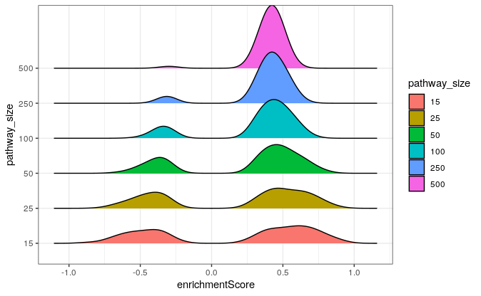

```r
random_es %>%
  ggplot2::ggplot(ggplot2::aes(enrichmentScore,
                               pathway_size,
                               fill = pathway_size)) +
  ggridges::geom_density_ridges() +
  ggplot2::theme_bw()
```

The distributions look different depending on the gene set size! If a gene set with 500 genes in it had an enrichment score of 0.75, we might expect that it would be called significant where a gene set with 15 genes in it with the same enrichment score might not be significant (based on the visuals in this plot alone!)

If we look at the normalized enrichment scores, the scores themselves are more comparable but we can still see some differences in the distributions.

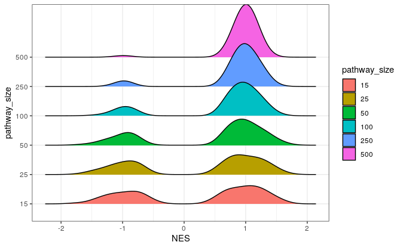

```r
random_es %>%
  ggplot2::ggplot(ggplot2::aes(NES,
                               pathway_size,
                               fill = pathway_size)) +
  ggridges::geom_density_ridges() +
  ggplot2::theme_bw()
```